# Linux w Systemach Wbudowanych

Piotr Zawadzki

2025-12-12

# **Ćwiczenie 6**

# Magistrala I2C

## Omówienie aplikacji

Schemat wszystkich połączeń elementów układu przedstawiono poniżej.

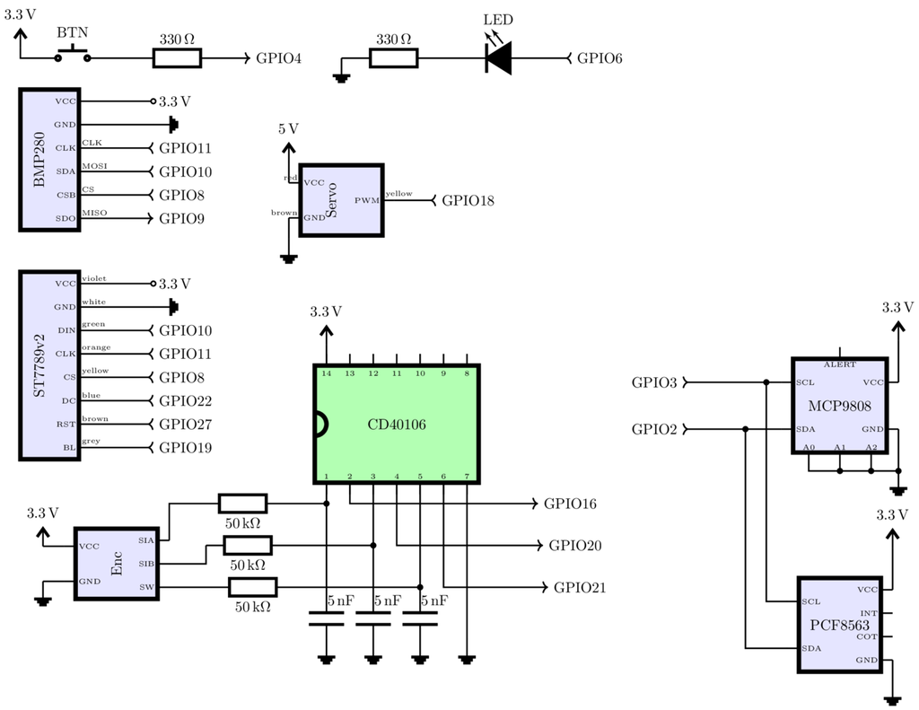

Rys. 6.9 Ilustracja połączeń układu laboratoryjnego.

### Opis funkcjonalny aplikacji

### Zawartość wyświetlacza

- lewy górny róg: bieżąca temperatura,
- prawy górny róg: wartość nastawy w zakresu 0-60 ustawiana enkoderem obrotowym,
- pierwsza linia po lewej: bieżący czas ustawiony w RTC,
- pierwsza linia po prawej: bieżąca data ustawiona w RTC,
- w dolnej części ekranu po lewej: czas systemowy `target`,
- w dolnej części ekranu po po prawej: data systemowa `target`.

### Zdarzenia

- Długie naciśnięcie przycisku – zatrzymanie aplikacji.
- Krótkie naciśnięcie przycisku – skopiowanie czasu systemowego do RTC,
- enkoder obrotowy - zmiana nastawy,
- nastawa poniżej temperatury wywołuje alarm,
- nastawa 60 zatrzymuje RTC,
- nastawa 59 uruchamia RTC,
- krótkie naciśnięcie przycisku enkodera - skopiowanie nastawy do pola sekund RTC,
- długie naciśnięcie przycisku enkodera - ustawienie czasu i daty systemowej `target` na podstawie zawartości RTC,
- działanie aplikacji można zakończyć kombinacją *Ctrl+C*. **Uwaga! *Ctrl+C* nie działa w terminalu Visual Studio Code**.

### Struktura aplikacji

Każdy z elementów zarządzany jest przez osobny wątek.

```cpp
std::thread display_task( display_thread, std::ref(appState), hardwareConfig.displayConfig) ;
// std::thread bmp280_task( bmp280_thread, std::ref(appState), hardwareConfig.bmp280Config) ;
std::thread mcp9808_task( mcp9808_thread, std::ref(appState), hardwareConfig.mcp9808Config) ;
std::thread pcf8563_task( pcf8563_thread, std::ref(appState), hardwareConfig.pcf8563Config) ;
std::thread lwsw_button_task( button_thread, std::ref(appState), hardwareConfig.buttonEvents) ;
std::thread rotary_task( rotary_encoder_thread, std::ref(appState), hardwareConfig.rotary_SIA, hardwareConfig.rotary_SIB) ;
std::thread rotary_button_task( rotary_button_thread, std::ref(appState), hardwareConfig.rotary_SW) ;
std::thread alarm_led_task( gpio_led_thread, std::ref(appState), hardwareConfig.LED ) ;
std::thread servo_task( servo_thread, std::ref(appState), hardwareConfig.PWM_Srv) ;
std::thread displayBacklight_task( pwmBacklight_thread, std::ref(appState), hardwareConfig.PWM_BL) ;
```

Wątki komunikują się ze sobą poprzez globalną zmienną

```cpp
typedef struct {
    std::atomic<bool> keepRunning;
    std::atomic<bool> setAlarm;
    std::atomic<std::chrono::steady_clock::time_point> alarmTime;
    std::atomic<int> tempThreshold; // in Celsius, temperature threshold for alarm
    std::atomic<float> mcpTemperature; // in Celsius, temperature measured by the sensor
    std::atomic<struct tm> pcfTime;
    std::atomic<bool> gpioButtonShortPress;
    std::atomic<bool> rotaryButtonShortPress;
    std::atomic<bool> rotaryButtonLongPress;
    const unsigned int alarmDuration_ms = 20000;
    const int tempThresholdDefault = 28;
} Application_state_t ;
```

Jak widać jest to struktura złożona z niezależnych elementów atomicznych, które mogą być w bezpieczny sposób odczytywane i aktualizowane przez wątki. Definicję sprzętowej konfiguracji wszystkich elementów zebrano w zmiennej `hardwareConfig`. Konfiguracja odpowiednich elementów jest przekazywana jako parametr do zainteresowanych wątków. Każdy wątek odpowiada za przydzielenie sobie zasobów i ich zwolnienie. W większości przypadków występujące w kodzie jawne zwalnianie zasobów może być pominięta, dzięki konstrukcji klas zarządzających zasobami zgodnie z zasadą RAII (*Resource Acquisition Is Initialization*), która w praktyce oznacza, że każdy zasób przydzielony w konstruktorze powinien być zwolniony w destruktorze. Destruktory są wykonywane zawsze, nawet gdy nastąpi rzucenie wyjątku (throw), więc stosowanie takiej zasady umożliwia bezpieczne zarządzanie zasobami.

Dzięki modułowej strukturze programu, kod procedur odpowiedzialnych za obsługę elementów jest samodzielny i jego analiza nie powinna nastręczać trudności.

Elementy wejściowe interfejsu aplikacji takie jak w poprzednim ćwiczeniu. Usunięto jedynie obsługę czujnika BMP280 korzystającego z magistrali SPI.

## Sensory

### Miernik temperatury MCP9808

Czujnik temperatury **MCP9808** posiada zestaw rejestrów umożliwiających konfigurację, odczyt danych i kontrolę czujnika. MCP9808 używa **adresowania I²C** do identyfikacji czujnika na magistrali. Domyślny 7-bitowy adres to `0x18`, który można zmienić na `0x19`, `0x1A` lub `0x1B` za pomocą pinów adresowych sprzętu. Szczegółowy opis rejestrów MCP9808 zamieszczono poniżej.

[output not shown]

- **Rozmiar:** 16 bitów
- **Cel:** Identyfikuje producenta.
- **Domyślna Wartość:** `0x0054` (tylko do odczytu).

- **Rozmiar:** 16 bitów
- **Cel:** Identyfikuje urządzenie i numer wersji.
- **Format:**
  - Bity 15–8: ID Urządzenia (`0x04` dla MCP9808).
  - Bity 7–0: Numer wersji.

- **Rozmiar:** 16 bitów
- **Cel:** Konfiguruje tryb operacyjny, ustawienia alarmu i histerezę.
- **Przypisania Bitów:**
  - Bit 15: Status Wyjścia Alarmu.
  - Bit 13: Kontrola Wyjścia Alarmu (0 = wyłączone, 1 = włączone).
  - Bity 9–8: Histereza Alarmu (00 = 0°C, 01 = +1.5°C, 10 = +3.0°C, 11 = +6.0°C).
  - Bit 7: Tryb Wyłączenia (0 = aktywny, 1 = wyłączenie).
  - Inne bity: Zarezerwowane dla dodatkowych ustawień.

- **Rozmiar:** 16 bitów
- **Cel:** Ustawia wysoki próg temperatury dla funkcji alarmu.
- **Format:** Kodowany w formacie uzupełnienia do 2 dla łatwego porównania.

- **Rozmiar:** 16 bitów
- **Cel:** Ustawia niski próg temperatury dla funkcji alarmu.
- **Format:** Kodowany w formacie uzupełnienia do 2.

- **Rozmiar:** 16 bitów
- **Cel:** Ustawia krytyczny próg temperatury dla funkcji alarmu.
- **Format:** Kodowany w formacie uzupełnienia do 2.

- **Rozmiar:** 16 bitów
- **Cel:** Zawiera bieżący odczyt temperatury z czujnika.
- **Format:**
  - Bity 15–13: Zarezerwowane.
  - Bity 12–0: Wartość temperatury w stopniach Celsjusza.
  - Przykład Konwersji:
    - Wartość `0x0640` reprezentuje +100°C.
    - Wartość `0xF940` reprezentuje -55°C.

### Zegar czasu rzeczywistego PCF8563T

**PCF8563T** posiada zestaw rejestrów dostępnych przez interfejs I²C, umożliwiających kontrolę i monitorowanie funkcji zegara czasu rzeczywistego (RTC). Domyślny 7-bitowy adres to **0x51**. Wartości czasu, daty i alarmu są w formacie BCD dla łatwiejszej czytelności. Poniżej znajduje się szczegółowy opis mapy rejestrów. Ostatnia kolumna zawiera maskę bitową, która informuje na których bitach kodowana jest informacja.

| Adres | Nazwa Rejestru | Funkcja | Wartość Domyślna | Maska |
| --- | --- | --- | --- | --- |
| 00h | **Control/Status 1** | Kontrola działania RTC | 00h | 0b0111 1111 |
| 01h | **Control/Status 2** | Kontrola alarmu i timera | 00h | 0b1111 1111 |
| 02h | **Sekundy** | Bieżące sekundy (format BCD) | 00h | 0b0111 1111 |
| 03h | **Minuty** | Bieżące minuty (format BCD) | 00h | 0b0111 1111 |
| 04h | **Godziny** | Bieżące godziny (format BCD, 12/24) | 00h | 0b0011 1111 |
| 05h | **Dni** | Bieżący dzień (1–31, format BCD) | 00h | 0b0011 1111 |
| 06h | **Dni Tygodnia** | Bieżący dzień tygodnia (0–6) | 00h | 0b0000 0111 |
| 07h | **Miesiące/Stulecie** | Bieżący miesiąc i bit stulecia | 00h | 0b0001 1111 |
| 08h | **Lata** | Bieżący rok (00–99, format BCD) | 00h | 0b1111 1111 |
| 09h | **Alarm Minutowy** | Minuty alarmu (BCD, wyłącz = 80h) | 80h | 0b0111 1111 |
| 0Ah | **Alarm Godzinowy** | Godziny alarmu (BCD, wyłącz = 80h) | 80h | 0b0011 1111 |
| 0Bh | **Alarm Dniowy** | Dzień alarmu (BCD, wyłącz = 80h) | 80h | 0b0011 1111 |
| 0Ch | **Alarm Dni Tygodnia** | Dzień tygodnia alarmu (wyłącz = 80h) | 80h | 0b0000 0111 |
| 0Dh | **Kontrola CLKOUT** | Kontrola wyjścia zegara | 00h | 0b0000 0111 |
| 0Eh | **Kontrola Timera** | Włączanie i tryb timera | 00h | 0b1110 0011 |
| 0Fh | **Timer** | Wartość timera | 00h | 0b1111 1111 |

#### **1. Rejestry Kontroli:**

- **Control/Status 1 (00h):**
  - Bit 7: TEST1 (do celów testowych)
  - Bit 6: STOP (zatrzymuje zegar, jeśli ustawiony)
  - Bit 5: TESTC (tryb testowy zegara)
  - Bity 4–0: Nie używane
- **Control/Status 2 (01h):**
  - Bit 7: Flaga Timera (TF)
  - Bit 6: Flaga Alarmu (AF)
  - Bit 5: Włączanie Timera (TI_TP)
  - Bit 4: Włączanie Przerwania Alarmu (AIE)
  - Bit 3: Włączanie Przerwania Timera (TIE)
  - Bity 2–0: Nie używane

#### **2. Rejestry Czasu i Daty (02h–08h):**

- **Format BCD:** Każda cyfra czasu i daty jest przechowywana w formacie binarno-kodowanej dziesiętnej (BCD).
- **Bit Stulecia:** Znajduje się w rejestrze Miesięcy (Bit 7) do obsługi przeskoków lat (2000/1900).

#### **3. Rejestry Alarmu (09h–0Ch):**

- Każdy rejestr przechowuje wartość alarmu dla minut, godzin, dni i dni tygodnia.
- Ustawienie rejestru na 80h wyłącza to pole alarmu.

#### **4. Rejestr Kontroli CLKOUT (0Dh):**

- Kontroluje częstotliwość wyjścia na pinie CLKOUT.
  - Bity 7–3: Nie używane
  - Bity 2–0:
    - 000: Wyłączone
    - 001: 32.768 kHz
    - 010: 1.024 kHz
    - 011: 32 Hz
    - 100: 1 Hz

#### **5. Rejestry Kontroli Timera i Timer (0Eh–0Fh):**

- **Rejestr Kontroli Timera:**
  - Bit 7: Włączanie Timera
  - Bit 6: Flaga Timera (ustawiana, gdy timer wygasa)
  - Bit 5: Włączanie Przerwania Timera
  - Bit 1–0: Tryb timera (00 = częstotliwość zegara / 4096, 01 = / 64, 10 = / 1, 11 = zewnętrzny)
- **Rejestr Timera:** Przechowuje wartość odliczania timera.

## Obsługa sensorów

### `I2CBus`

Klasa `I2CBus` zapewnia odczyt i zapis surowych danych z/do urządzeń podłączonych do magistrali I2C.

```cpp
class I2CBus {
public:
    // Constructor
    I2CBus(const std::string &deviceFile, uint8_t deviceAddress);

    // Destructor
    ~I2CBus();

    // Write 8-bit value to a register
    void write8(uint8_t reg, uint8_t value);

    // Read 8-bit value from a register
    uint8_t read8(uint8_t reg);

    // Write 16-bit value to a register
    void write16(uint8_t reg, uint16_t value);

    // Read 16-bit value from a register
    uint16_t read16(uint8_t reg);

    // Write a block of data to a register
    template <size_t N>
    void writeBlock(uint8_t reg, const std::array<uint8_t, N> &data);

    // Read a block of data from a register
    template <size_t N>
    void readBlock(uint8_t reg, std::array<uint8_t, N> &data);

private:
    int fd_;
    uint8_t address_;
};
```

### `MCP9808`

Klasa `MCP9808` wykorzystuje `I2CBus` do transmisji. Metody zawarte w klasie zajmują się jedynie interpretacją i formatowaniem danych.

```cpp
class MCP9808 {
public:
    struct Config {
       std::string i2cBusDevice;   // "/dev/i2c-1"
        uint8_t i2cAddress;    // 0x18
    };
    MCP9808(const std::string &i2cBusDevice, int address = 0x18);
    ~MCP9808();

    float getTemperature();
    void setUpperAlarmTemperature(float temperature);
    void enableComparatorMode();
    uint16_t getManufacturerID();
    uint16_t getDeviceID();

private:
    I2CBus i2cBus_;

    static constexpr uint8_t MANUFACTURER_ID_REG = 0x06;
    static constexpr uint8_t DEVICE_ID_REG = 0x07;
    static constexpr uint8_t CONFIG_REG = 0x01;
    static constexpr uint8_t TEMP_REG = 0x05;
    static constexpr uint8_t TUPPER_REG = 0x02;
    static constexpr uint8_t TLOWER_REG = 0x03;
    static constexpr uint8_t TCRIT_REG = 0x04;

    // Expected Manufacturer and Device ID
    static constexpr uint16_t EXPECTED_MANUFACTURER_ID = 0x0054;
    static constexpr uint16_t EXPECTED_DEVICE_ID = 0x0400; // Example device ID

    float convertRawTemperature(uint16_t rawTemp);
};
```

### `PCF8563`

Klasa `PCF8563` wykorzystuje `I2CBus` do transmisji. Metody zawarte w klasie zajmują się jedynie interpretacją i formatowaniem danych.

```cpp
class PCF8563 {
public:
    struct Config {
        std::string i2cBusDevice;   // "/dev/i2c-1"
        uint8_t i2cAddress;    // 0x51
    };
    PCF8563(const std::string &i2cBusDevice, uint8_t address = 0x51);
    ~PCF8563();

    void setTime(uint8_t hours, uint8_t minutes, uint8_t seconds);
    void setDate(uint8_t day, uint8_t month, uint8_t year);
    std::array<uint8_t, 3> getTime();
    std::array<uint8_t, 4> getDate();
    void setAlarm(uint8_t hour, uint8_t minute, uint8_t day = 0x80, uint8_t weekday = 0x80);
    void clearAlarm();
    bool Start();
    bool Stop();
    bool Reset();
    void setTimeAndDate(const struct tm & wall);
    struct tm getTimeAndDate();

private:
    I2CBus i2cBus_;

    static uint8_t toBCD(uint8_t value);
    static uint8_t fromBCD(uint8_t value);
};
```

## Zadania do wykonania

Repozytorium ćwiczenia https://github.com/pzktit/lwsw-cw6-student. Wykonaj jego fork lub bezpośrednio sklonuj do lokalnego katalogu. Sklonuj je do bieżącego katalogu pomijając historię zmian

```bash
git clone --depth 1 --branch main --single-branch https://github.com/pzktit/lwsw-cw6-student.git cw6
```

### 1. Konfiguracja platformy sprzętowej

1. **Sprawdzenie obecności w systemie dostępnych nakładek DT związanych z kontrolą szyn I2C**
- Przy użyciu komendy `ls` sprawdź dostępność nakładek DT obsługujących szyny I2C. Nakładki znajdują się w katalogu `/boot/firmware/overlays`.

  ```bash
  ls *i2c*
  ```

1. **Właściwości nakładek**. Korzystając z komendy `dtoverlay -h` uzyskaj opis opcji dostępnych dla nakładek z sufiksem `*-pi5` w nazwie.
2. **Inspekcja konfiguracji w pliku `config.txt`**. Wyświetl zawartość `config.txt` (komenda `cat`) i sprawdź, czy nakładka/nakładki dotyczące I2C są załadowane.
3. **Sprawdzenie konfiguracji miksera pinów**. Korzystając z `pinctrl` znajdź piny na których można aktywować I2C.

   ```bash
   pinctrl funcs 1-27 | grep -E "SCL|SDA"
   ```

4. **Sprawdzenie funkcji pinów wykorzystywanej magistrali I2C**. Zastosowana w ćwiczeniu konfiguracja wykorzystuje magistralę I2C1. Sprawdź konfigurację przypisanych do niej pinów SDL i SDA.

   ```bash
   pinctrl get 2,3
   ```

Wykonaj zrzuty ekranu w punktach 3 i 4 (6.1.1 i 6.1.2) zawierające wynik działania odpowiednich komend. Zrzut zamieść w sprawozdaniu.

### 2. Interfejs linii komend

1. Przenieś czas z systemu `host` (VM) na system `target` (Pi5). W systemie `host` wydaj komendę

   ```bash
   ssh target-0x "sudo date -s \"$(date -u '+%Y-%m-%d %H:%M:%S')\""
   ```

2. Sprawdź magistrale dostępne w systemie

   ```bash
   i2cdetect -l
   ```

3. Sprawdź urządzenia podpięte do magistrali `i2c-1` (`/dev/i2c-1`)

   ```bash
   i2cdetect -y -r 1
   ```

4. Pobierz ID wytwórcy oraz ID urządzenia z rejestrów MCP9808

   ```bash
   i2cget -y 1 0x18 0x06 w ; i2cget -y 1 0x18 0x07 w
   ```

5. Pobierz bieżący czas ustawiony w sensorze PCF8563 (zauważ użycie odpowiednich masek eliminujących nieużywane bity)

   ```bash
   secreg=$(i2cget -y 1 0x51 0x02 b) && minreg=$(i2cget -y 1 0x51 0x03 b) &&  hrsreg=$(i2cget -y 1 0x51 0x04 b)
   printf "%02x:%02x:%02x\n" $(( hrsreg & 0x3f )) $(( minreg & 0x7f )) $(( secreg & 0x7f))
   ```

6. Ustaw czas `17:16`

   ```bash
   i2cset -y 1 0x51 0x04 0x17 b && i2cset -y 1 0x51 0x03 0x16 b && i2cset -y 1 0x51 0x02 0x00 b
   ```

   Pobierz ponownie czas zapisany w rejestrach zegara.
7. (Pomijamy w sezonie 2025/26) Uruchom poniższy one-liner pobierający 20 razy ID sensora MCP9808. Na oscyloskopie uzyskaj przebieg zapytania i odpowiedzi (2 osobne przebiegi)

   ```bash
   for k in `seq 1 20` ; do echo -n "$k: " ; i2cget -y 1 0x18 0x06 w ; sleep 1 ; done
   ```

### 3. Praca z kodem aplikacji

**Polecenie**

Zbuduj dostarczony kod źródłowy. Miejsca wymagające modyfikacji oznaczono jako `TODO`. Stosuj się do opisów zamieszczonych w komentarzach. Przed wykonaniem zrzutu ekranu nie kasuj komentarzy zawierających polecenie.

**Uwaga!** Aby ustawić czas systemowy z poziomu aplikacji należy jej binariom nadać odpowiednie prawa. Gdy binaria aplikacji są już na systemie `target` należy wykonać komendę

```bash
sudo setcap cap_sys_time+ep /home/pi/app
getcap /home/pi/app
```

**Każdorazowa zmiana binariów, np. na skutek rekompilacji, wymaga powtórnego nadania uprawnień!**